# Contaminant removal in low-biomass 16S data

Benchmarking decontam and simple filters against a mock-community ground truth

Author

Joan Gordó Guardia

Published

November 18, 2026

```r
library(decontam)
library(ggplot2)
library(dplyr)
library(tidyr)
library(knitr)

root <- normalizePath("..")   # Quarto runs chunks from analysis/
for (f in list.files(file.path(root, "R"), full.names = TRUE)) source(f)

theme_set(theme_minimal(base_size = 12))
pal <- c(Expected = "#2C7FB8", Contaminant = "#BDBDBD")

d <- load_dataset(file.path(root, "data"))
counts  <- d$counts
samples <- d$samples
tax     <- d$taxonomy

is_neg   <- samples$is_neg
expected <- setNames(tax$expected, tax$asv_id)

# Evaluation universe: ASVs observed in at least one dilution sample.
# ASVs seen only in the blank cannot contaminate the samples being cleaned.
in_mock     <- colSums(counts[!is_neg, ]) > 0
mock_counts <- counts[!is_neg, in_mock]
mock_exp    <- expected[in_mock]
```

## Why this matters

In samples with very little bacterial DNA (biopsies, swabs, blood, ascitic fluid) the reagents and the lab environment contribute DNA of their own. The less real signal there is, the larger the share of reads that come from contamination, and the easier it is to “discover” a microbiome that was never there.

This is an independent project, not affiliated with or endorsed by any institution. The question comes from my own experience analysing low-biomass 16S data, but no data, code or documents from any previous work are used here. Typical cleaning workflows with the [decontam](https://benjjneb.github.io/decontam/) package are rarely evaluated, because on real samples there is no way to know which taxa are truly contaminants. Here such a workflow is built from scratch and **evaluated** on a public dataset where the answer is known.

## Data

Karstens et al. (2019, *mSystems*) sequenced a commercial mock community (ZymoBIOMICS) in a series of eight three-fold dilutions plus one extraction blank. Any read that does not belong to the mock community is, by definition, an error or a contaminant. That gives a ground truth to score every method against.

```r
samples |>
  transmute(
    Sample = sample_id,
    Description = description,
    `DNA conc. (ng/µL)` = dna_conc,
    Reads = format(total_reads, big.mark = ","),
    `% contaminant reads` = round(
      100 * rowSums(counts[, !expected]) / rowSums(counts), 1)
  ) |>
  kable(align = "llrrr")
```

| Sample | Description | DNA conc. (ng/µL) | Reads | % contaminant reads |
| --- | --- | --- | --- | --- |
| D0 | MC_Neat | 138.8 | 251,419 | 0.1 |
| D1 | MC_1:3 | 109.2 | 172,915 | 0.1 |
| D2 | MC_1:9 | 105.8 | 250,861 | 1.8 |
| D3 | MC_1:27 | 60.6 | 247,581 | 4.5 |
| D4 | MC_1:81 | 34.9 | 216,341 | 12.0 |
| D5 | MC_1:243 | 22.6 | 136,081 | 27.9 |
| D6 | MC_1:729 | 20.0 | 128,053 | 64.5 |
| D7 | MC_1:2187 | 11.4 | 41,071 | 55.8 |
| D8 | MC_1:6561 | 13.8 | 40,927 | 80.1 |
| Blank | Urine Extraction Blank | 10.5 | 189,779 | 98.8 |

The dataset has 1414 ASVs, of which 9 belong to the mock community; 946 ASVs appear in at least one dilution and form the evaluation set.

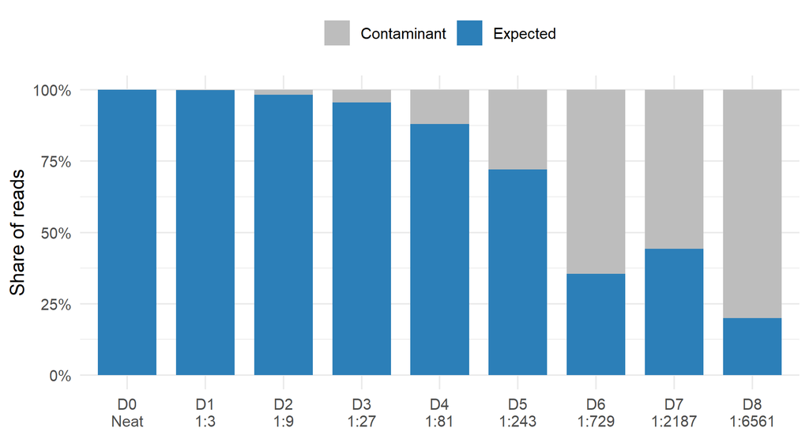

Figure 1: Share of reads per sample that belong to the mock community (blue) or are contaminants (grey). Contamination grows as input biomass falls.

```r
comp <- tibble(
  sample_id = rownames(mock_counts),
  Expected = rowSums(mock_counts[, mock_exp]),
  Contaminant = rowSums(mock_counts[, !mock_exp])
) |>
  left_join(samples, by = "sample_id") |>
  pivot_longer(c(Expected, Contaminant), names_to = "origin",
               values_to = "reads") |>
  group_by(sample_id) |>
  mutate(share = reads / sum(reads)) |>
  ungroup() |>
  mutate(label = factor(paste0(sample_id, "\n", sub("MC_", "", description)),
                        levels = unique(paste0(samples$sample_id, "\n",
                                               sub("MC_", "", samples$description)))),
         origin = factor(origin, levels = c("Contaminant", "Expected")))

ggplot(comp, aes(label, share, fill = origin)) +
  geom_col(width = 0.75) +
  scale_y_continuous(labels = scales::percent) +
  scale_fill_manual(values = pal) +
  labs(x = NULL, y = "Share of reads", fill = NULL) +
  theme(legend.position = "top")
```

## Step 1. Low-read samples

A common rule drops samples with fewer than 1,000 reads (low-biomass tissue and swabs), or fewer reads than the median of the negative controls (very-low-biomass fluids).

```r
low_fixed  <- flag_low_read_samples(counts, is_neg, "fixed", 1000)
low_median <- flag_low_read_samples(counts, is_neg, "neg_median")
```

The fixed rule removes nothing: the smallest sample has 40,927 reads. Note that read depth alone would not have warned us: the most diluted sample is 80% contaminant while still having tens of thousands of reads. With a single blank of 189,779 reads, the “median of the controls” rule would discard 5 of the 9 dilutions (D1, D5, D6, D7, D8), which shows that it only makes sense with several controls and genuinely shallow samples.

## Step 2. Methods compared

```r
flag_from <- function(res) setNames(res$contaminant, res$asv_id)

methods <- list(
  "Abundance filter (>1% in >=1 sample)" =
    flag_low_abundance(counts, is_neg, min_rel = 0.01, min_samples = 1),
  "Abundance filter (>0.2% in >=3 samples)" =
    flag_low_abundance(counts, is_neg, min_rel = 0.002, min_samples = 3),
  "Present in negative control" =
    flag_in_negative(counts, is_neg),
  "Control-dominant" =
    flag_control_dominant(counts, is_neg),
  "decontam frequency (t = 0.1)" =
    flag_from(run_decontam(counts, samples$dna_conc, is_neg, "frequency", 0.1)),
  "decontam frequency (t = 0.5)" =
    flag_from(run_decontam(counts, samples$dna_conc, is_neg, "frequency", 0.5)),
  "decontam prevalence (t = 0.1)" =
    flag_from(run_decontam(counts, samples$dna_conc, is_neg, "prevalence", 0.1)),
  "decontam prevalence (t = 0.5)" =
    flag_from(run_decontam(counts, samples$dna_conc, is_neg, "prevalence", 0.5))
)
methods <- lapply(methods, function(f) f[in_mock])

low_bio <- c("D6", "D7", "D8")   # the three most diluted samples

results <- bind_rows(lapply(names(methods), function(m) {
  cm <- classification_metrics(methods[[m]], mock_exp)
  rl <- read_level_metrics(mock_counts, methods[[m]], mock_exp)
  tibble(
    Method = m,
    `Contaminant ASVs removed` = cm$tp,
    `Mock ASVs removed` = cm$fp,
    `ASV sensitivity` = cm$sensitivity,
    `Contaminant reads removed, D6–D8 (%)` =
      mean(rl$pct_contam_reads_removed[rl$sample_id %in% low_bio]),
    `Contaminant reads left, D8 (%)` =
      rl$pct_contam_after[rl$sample_id == "D8"],
    `Max. mock reads lost (%)` = max(rl$pct_mock_reads_lost)
  )
}))

results |>
  kable(digits = c(0, 0, 0, 3, 1, 1, 1),
        align = "lrrrrrr")
```

| Method | Contaminant ASVs removed | Mock ASVs removed | ASV sensitivity | Contaminant reads removed, D6–D8 (%) | Contaminant reads left, D8 (%) | Max. mock reads lost (%) |
| --- | --- | --- | --- | --- | --- | --- |
| Abundance filter (>1% in >=1 sample) | 918 | 0 | 0.980 | 69.6 | 53.3 | 0.0 |
| Abundance filter (>0.2% in >=3 samples) | 909 | 0 | 0.970 | 66.3 | 55.6 | 0.0 |
| Present in negative control | 194 | 3 | 0.207 | 49.6 | 77.4 | 33.9 |
| Control-dominant | 84 | 0 | 0.090 | 10.4 | 78.8 | 0.0 |
| decontam frequency (t = 0.1) | 34 | 0 | 0.036 | 13.9 | 77.6 | 0.0 |
| decontam frequency (t = 0.5) | 246 | 0 | 0.263 | 71.4 | 52.5 | 0.0 |
| decontam prevalence (t = 0.1) | 56 | 0 | 0.060 | 2.0 | 80.0 | 0.0 |
| decontam prevalence (t = 0.5) | 194 | 0 | 0.207 | 49.6 | 69.4 | 0.0 |

Every method is scored two ways, because they tell different stories:

- **ASV level**: how many of the contaminant ASVs were removed, and whether any genuine mock ASV was removed by mistake.
- **Read level**: how much of the contaminant *signal* disappears from the low-biomass samples, and how much genuine signal is lost.

### What the table shows

**Removing everything seen in the blank is harmful.** It is the only method that deletes genuine taxa (3 mock ASVs, up to 34% of the true reads in a sample). Mock DNA ends up in the blank through cross-contamination during processing, so the blank contains real taxa too.

**decontam’s default threshold is conservative.** At `threshold = 0.1` the frequency method removes only 14% of contaminant reads in the most diluted samples; at 0.5 this rises to 71%, still without touching a single mock ASV. Both values are used in practice, often without being reported; the choice matters more than it seems.

**With one blank, the prevalence method has almost nothing to work with.** A single negative control means each ASV is either present or absent in it, so the method collapses into a softer version of “present in the blank”. Its performance here says more about the study design than about the method.

**The abundance filter looks best, but this dataset flatters it.** All mock taxa are abundant by construction, so a >1% filter cannot hurt them. In real samples, rare but genuine taxa would be removed. Treat that row as an upper bound, not as a recommendation.

**Nothing cleans the most diluted sample.** Even the most effective method leaves 53% of D8’s reads as contaminants.

## Step 3. Why the frequency method misses so much

The frequency method models how each ASV’s relative abundance changes with input DNA concentration: contaminants are added in roughly constant amounts, so their *share* should fall as real DNA increases.

```r
freq <- run_decontam(counts, samples$dna_conc, is_neg, "frequency", 0.1)
freq <- freq[match(names(mock_exp), freq$asv_id), ]
auc <- score_auc(freq$score, mock_exp)

unscored_contam <- !freq$scored & !mock_exp
unscored_share <- rowSums(mock_counts[low_bio, unscored_contam]) /
  rowSums(mock_counts[low_bio, !mock_exp])
```

Two separate problems appear:

1. **The score itself works.** Among the 271 ASVs it can score, it separates contaminants from mock taxa almost perfectly (AUC = 0.993). The issue is where the cut-off is put.
2. **Most contaminant ASVs cannot be scored at all.** An ASV needs to appear in at least two samples to fit the model; 675 of 946 ASVs appear in only one. Those unscored contaminants alone account for 25% to 30% of the contaminant reads in D6–D8, and no threshold can remove them.

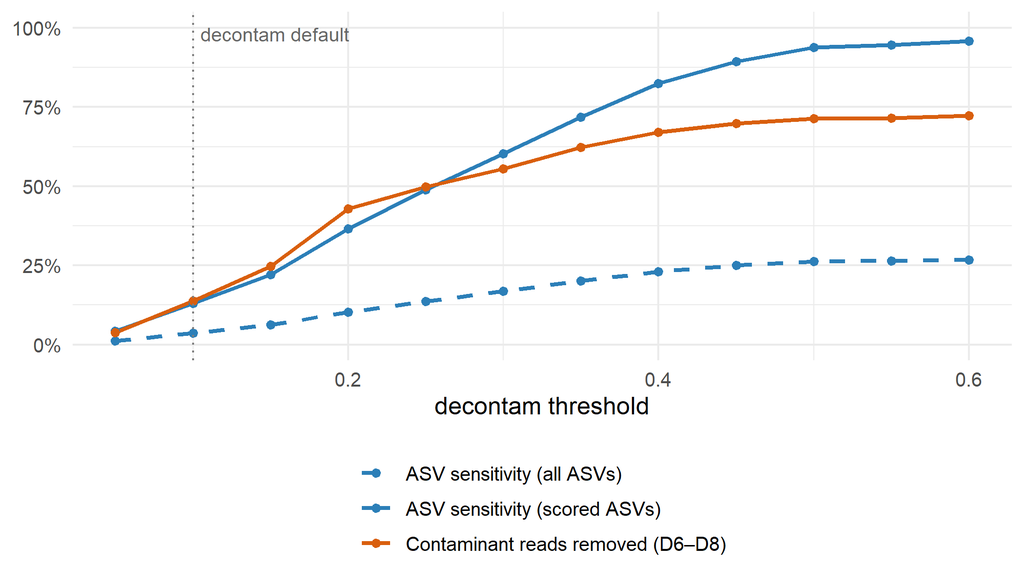

Figure 2: Frequency method across thresholds. ASV-level sensitivity is computed over scorable ASVs (solid) and over all contaminant ASVs (dashed). Read-level removal is averaged over D6–D8. No mock ASV is removed at any threshold shown.

```r
thresholds <- seq(0.05, 0.6, by = 0.05)
sweep <- bind_rows(lapply(thresholds, function(t) {
  flag <- setNames(freq$scored & freq$score < t, freq$asv_id)
  cm <- classification_metrics(flag, mock_exp)
  rl <- read_level_metrics(mock_counts, flag, mock_exp)
  tibble(
    threshold = t,
    `ASV sensitivity (scored ASVs)` =
      sum(flag & !mock_exp) / sum(freq$scored & !mock_exp),
    `ASV sensitivity (all ASVs)` = cm$sensitivity,
    `Contaminant reads removed (D6–D8)` =
      mean(rl$pct_contam_reads_removed[rl$sample_id %in% low_bio]) / 100,
    mock_removed = cm$fp
  )
}))
stopifnot(all(sweep$mock_removed == 0))

sweep |>
  select(-mock_removed) |>
  pivot_longer(-threshold) |>
  ggplot(aes(threshold, value, colour = name, linetype = name)) +
  geom_line(linewidth = 0.9) +
  geom_point(size = 1.6) +
  geom_vline(xintercept = 0.1, colour = "grey50", linetype = "dotted") +
  annotate("text", x = 0.105, y = 0.98, label = "decontam default",
           hjust = 0, size = 3.3, colour = "grey40") +
  scale_y_continuous(labels = scales::percent, limits = c(0, 1)) +
  scale_colour_manual(values = c("#2C7FB8", "#2C7FB8", "#D95F0E")) +
  scale_linetype_manual(values = c("dashed", "solid", "solid")) +
  labs(x = "decontam threshold", y = NULL, colour = NULL, linetype = NULL) +
  theme(legend.position = "bottom", legend.direction = "vertical")
```

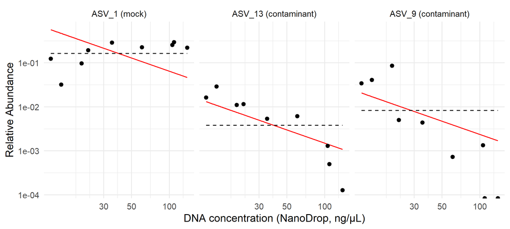

Figure 3: Relative abundance against DNA concentration for one mock ASV and the two most abundant scorable contaminants. Red: decontam’s contaminant model (frequency inversely proportional to DNA concentration). Dashed: non-contaminant model (constant frequency). Only these two models are shown; extra fits drawn over them can mislead.

```r
top_contam <- names(sort(colSums(mock_counts[, !mock_exp & freq$scored]),
                         decreasing = TRUE))[1:2]
show_asvs <- c(names(mock_exp)[mock_exp][1], top_contam)

# Normalise on the full table *before* subsetting (otherwise frequencies
# would be relative to these three ASVs only), and label each panel with
# the ASV's true origin.
ex <- relative_abundance(mock_counts)[, show_asvs]
colnames(ex) <- paste0(show_asvs, ifelse(mock_exp[show_asvs],
                                         " (mock)", " (contaminant)"))

plot_frequency(ex, colnames(ex), conc = samples$dna_conc[!is_neg],
               normalize = FALSE) +
  labs(x = "DNA concentration (NanoDrop, ng/µL)")
```

## Effect on the data

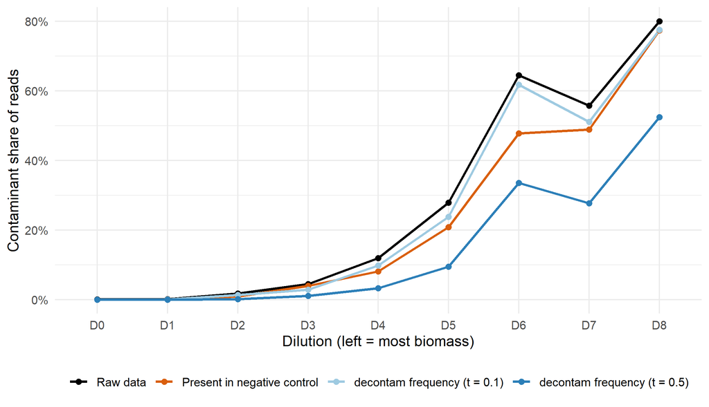

Figure 4: Contaminant share per sample before and after cleaning.

```r
show <- c("Raw data" = NA,
          "Present in negative control" = "Present in negative control",
          "decontam frequency (t = 0.1)" = "decontam frequency (t = 0.1)",
          "decontam frequency (t = 0.5)" = "decontam frequency (t = 0.5)")

ba <- bind_rows(lapply(names(show), function(lbl) {
  flag <- if (is.na(show[[lbl]])) setNames(rep(FALSE, length(mock_exp)),
                                           names(mock_exp))
          else methods[[show[[lbl]]]]
  read_level_metrics(mock_counts, flag, mock_exp) |>
    mutate(method = lbl)
})) |>
  mutate(method = factor(method, levels = names(show)),
         sample_id = factor(sample_id, levels = rownames(mock_counts)))

ggplot(ba, aes(sample_id, pct_contam_after / 100, colour = method,
               group = method)) +
  geom_line(linewidth = 0.9) +
  geom_point(size = 1.8) +
  scale_y_continuous(labels = scales::percent) +
  scale_colour_manual(values = c("black", "#D95F0E", "#9ECAE1", "#2C7FB8")) +
  labs(x = "Dilution (left = most biomass)", y = "Contaminant share of reads",
       colour = NULL) +
  theme(legend.position = "bottom")
```

## Limitations

- **One dataset, one blank.** The prevalence method and any combination that uses it cannot be judged fairly with a single negative control.
- **Nine true ASVs.** ASV-level specificity rests on very few genuine taxa, so “no mock ASV removed” is encouraging but not a precise estimate.
- **A mock community is easier than a real sample.** Its true taxa are all abundant, which favours abundance-based filters.
- **DNA quantification.** Concentrations were measured with NanoDrop, which is imprecise at low concentrations, exactly where the frequency method needs the most information. Fluorometric (Qubit/PicoGreen) or qPCR quantification would be a better input.
- **“Contaminant” here means “not in the mock”.** That bundles reagent contamination, cross-talk between samples and sequencing errors together.

## Practical takeaways (preliminary)

1. Do not remove everything found in the negative controls.
2. Choose decontam’s threshold deliberately and report it; 0.1 is a cautious default, not a property of the data.
3. Plan for several negative controls per batch if you want to use the prevalence method at all.
4. In very-low-biomass samples, assume a sizeable share of the remaining reads is still contamination, and say so when reporting results.

## Next

Part 2 uses simulation to vary what this dataset cannot: the number of negative controls, the precision of DNA quantification and cross-contamination of the blanks. Part 3 turns both parts into a decision guide and an end-to-end workflow.

## Reference

Karstens L, Asquith M, Davin S, et al. (2019). Controlling for contaminants in low-biomass 16S rRNA gene sequencing experiments. *mSystems* 4(4): e00290-19. https://doi.org/10.1128/mSystems.00290-19

Davis NM, Proctor DM, Holmes SP, Relman DA, Callahan BJ (2018). Simple statistical identification and removal of contaminant sequences in marker-gene and metagenomics data. *Microbiome* 6:226. https://doi.org/10.1186/s40168-018-0605-2

```
R4.6.1 | decontam 1.32.0
```